# Customer Churn Prediction with Spark

Detect and predict customer churn with machine learning models is a common problem Data Scientists are often confronted with in a customer-facing business. In this project I have built a machine learning model to predict customer churn. To be able to use the model not only on small datasets, but also on "big data", I have used Apache Spark's machine learning library MLlib and PySpark.

#### Import Libraries

```python
# import libraries
import pyspark
from pyspark import SparkConf
from pyspark.sql import SparkSession

from pyspark.sql.window import Window
from pyspark.sql.functions import udf, isnan, min, max, sum, count, desc, expr, avg
from pyspark.sql.types import IntegerType, LongType

from pyspark.ml.feature import StandardScaler, VectorAssembler, MinMaxScaler
from pyspark.ml.evaluation import MulticlassClassificationEvaluator
from pyspark.ml.tuning import CrossValidator, ParamGridBuilder, CrossValidatorModel
from pyspark.ml import Pipeline
from pyspark.ml.classification import DecisionTreeClassifier, RandomForestClassifier, \
LogisticRegression, GBTClassifier, LogisticRegressionModel, GBTClassificationModel, \
RandomForestClassificationModel, DecisionTreeModel

import matplotlib.pyplot as plt
import seaborn as sns
import datetime
import numpy as np
import pandas as pd
```

#### Set up a Spark session

```python
# Set Configurations for Spark session
config = pyspark.SparkConf().setAll([('spark.executor.memory', '16g'), ('spark.executor.cores', '3'), ('spark.cores.max', '3'), ('spark.driver.memory','16g')])
```

```python
# create a Spark session
spark = SparkSession \
    .builder \
    .config(conf=config)\
    .appName('Churn Analysis with Spark') \
    .getOrCreate()
```

```python
# Check, if Spark session was setup correctly
spark.sparkContext.getConf().getAll()
```

```
[('spark.driver.host', 'd7c50d1d5820'),
 ('spark.executor.id', 'driver'),
 ('spark.driver.memory', '16g'),
 ('spark.cores.max', '3'),
 ('spark.executor.memory', '16g'),
 ('spark.app.id', 'local-1561905727558'),
 ('spark.rdd.compress', 'True'),
 ('spark.driver.port', '44137'),
 ('spark.serializer.objectStreamReset', '100'),
 ('spark.master', 'local[*]'),
 ('spark.executor.cores', '3'),
 ('spark.submit.deployMode', 'client'),
 ('spark.app.name', 'Churn Analysis with Spark'),
 ('spark.ui.showConsoleProgress', 'true')]
```

```python
spark
```

**SparkSession - in-memory**

**SparkContext**

[Spark UI](http://d7c50d1d5820:4040)

**Version**

`v2.4.3`

**Master**

`local[*]`

**AppName**

`Churn Analysis with Spark`

# Load and Clean Dataset

The following steps will be processed with subset of a 12GB dataset named `mini_sparkify_event_data.json`. First of all the dataset the dataset will be loaded, cleaned and checked for invalid or missing data.

```python
# Load dataset
df = spark.read.json('mini_sparkify_event_data.json')
```

```python
# Show all columns and data types
df.printSchema()
```

```
root
 |-- artist: string (nullable = true)
 |-- auth: string (nullable = true)
 |-- firstName: string (nullable = true)
 |-- gender: string (nullable = true)
 |-- itemInSession: long (nullable = true)
 |-- lastName: string (nullable = true)
 |-- length: double (nullable = true)
 |-- level: string (nullable = true)
 |-- location: string (nullable = true)
 |-- method: string (nullable = true)
 |-- page: string (nullable = true)
 |-- registration: long (nullable = true)
 |-- sessionId: long (nullable = true)
 |-- song: string (nullable = true)
 |-- status: long (nullable = true)
 |-- ts: long (nullable = true)
 |-- userAgent: string (nullable = true)
 |-- userId: string (nullable = true)
```

```python
# Show first 5 rows
df.head(5)
```

```
[Row(artist='Martha Tilston', auth='Logged In', firstName='Colin', gender='M', itemInSession=50, lastName='Freeman', length=277.89016, level='paid', location='Bakersfield, CA', method='PUT', page='NextSong', registration=1538173362000, sessionId=29, song='Rockpools', status=200, ts=1538352117000, us…
 Row(artist='Five Iron Frenzy', auth='Logged In', firstName='Micah', gender='M', itemInSession=79, lastName='Long', length=236.09424, level='free', location='Boston-Cambridge-Newton, MA-NH', method='PUT', page='NextSong', registration=1538331630000, sessionId=8, song='Canada', status=200, ts=1538352…
 Row(artist='Adam Lambert', auth='Logged In', firstName='Colin', gender='M', itemInSession=51, lastName='Freeman', length=282.8273, level='paid', location='Bakersfield, CA', method='PUT', page='NextSong', registration=1538173362000, sessionId=29, song='Time For Miracles', status=200, ts=153835239400…
 Row(artist='Enigma', auth='Logged In', firstName='Micah', gender='M', itemInSession=80, lastName='Long', length=262.71302, level='free', location='Boston-Cambridge-Newton, MA-NH', method='PUT', page='NextSong', registration=1538331630000, sessionId=8, song='Knocking On Forbidden Doors', status=200,…
 Row(artist='Daft Punk', auth='Logged In', firstName='Colin', gender='M', itemInSession=52, lastName='Freeman', length=223.60771, level='paid', location='Bakersfield, CA', method='PUT', page='NextSong', registration=1538173362000, sessionId=29, song='Harder Better Faster Stronger', status=200, ts=15…
```

```python
# Schow summary statistics
df.describe().show()
```

```
+-------+------------------+----------+---------+------+------------------+--------+-----------------+------+-----------------+------+-------+--------------------+-----------------+--------------------+------------------+--------------------+--------------------+-----------------+
|summary|            artist|      auth|firstName|gender|     itemInSession|lastName|           length| level|         location|method|   page|        registration|        sessionId|                song|            status|                  ts|           userAgent|           userId|
+-------+------------------+----------+---------+------+------------------+--------+-----------------+------+-----------------+------+-------+--------------------+-----------------+--------------------+------------------+--------------------+--------------------+-----------------+
|  count|            228108|    286500|   278154|278154|            286500|  278154|           228108|286500|           278154|286500| 286500|              278154|           286500|              228108|            286500|              286500|              278154|           286500|
|   mean| 551.0852017937219|      null|     null|  null|114.41421291448516|    null|249.1171819778458|  null|             null|  null|   null|1.535358834084427...|1041.526554973822|            Infinity|210.05459685863875|1.540956889810483...|                null|59682.02278593872|
| stddev|1217.7693079161374|      null|     null|  null|129.76726201140994|    null|99.23517921058361|  null|             null|  null|   null| 3.291321616327586E9|726.7762634630741|                 NaN| 31.50507848842214|1.5075439608226302E9|                null|109091.9499991047|
|    min|               !!!| Cancelled| Adelaida|     F|                 0|   Adams|          0.78322|  free|       Albany, OR|   GET|  About|       1521380675000|                1|ÃÂg ÃÂtti Gr...|               200|       1538352117000|"Mozilla/5.0 (Mac...|                 |
|    max| ÃÂlafur Arnalds|Logged Out|   Zyonna|     M|              1321|  Wright|       3024.66567|  paid|Winston-Salem, NC|   PUT|Upgrade|       1543247354000|             2474|ÃÂau hafa slopp...|               404|       1543799476000|Mozilla/5.0 (comp...|               99|
+-------+------------------+----------+---------+------+------------------+--------+-----------------+------+-----------------+------+-------+--------------------+-----------------+--------------------+------------------+--------------------+--------------------+-----------------+
```

```python
# Show number of rows
df.count()
```

```
286500
```

```python
# Check for missing values
for column in df.columns:
    nan_missings = df.filter(isnan(df[column])).count()
    null_missings =  df.filter(df[column].isNull()).count()
    empty_missings = df.filter(df[column] == '').count()
    total_missings = nan_missings + null_missings + empty_missings

    # If column has missing values, print details
    if total_missings > 0:
        print(f'{column}: {total_missings} missing values: {nan_missings} Nan, {null_missings} Null, {empty_missings} Empty.')
```

```
artist: 58392 missing values: 0 Nan, 58392 Null, 0 Empty.
firstName: 8346 missing values: 0 Nan, 8346 Null, 0 Empty.
gender: 8346 missing values: 0 Nan, 8346 Null, 0 Empty.
lastName: 8346 missing values: 0 Nan, 8346 Null, 0 Empty.
length: 58392 missing values: 0 Nan, 58392 Null, 0 Empty.
location: 8346 missing values: 0 Nan, 8346 Null, 0 Empty.
registration: 8346 missing values: 0 Nan, 8346 Null, 0 Empty.
song: 58392 missing values: 0 Nan, 58392 Null, 0 Empty.
userAgent: 8346 missing values: 0 Nan, 8346 Null, 0 Empty.
userId: 8346 missing values: 0 Nan, 0 Null, 8346 Empty.
```

```python
# Drop rows with missing user id
df = df.where(df.userId != '')
df.count() # Show number of rows after removal of rows with missing ids
```

```
278154
```

```python
# Drop duplicates
df = df.dropDuplicates()
df.count() # Show number of rows after removal of dupllicates (none!)
```

```
278154
```

# Exploratory Data Analysis (EDA)

To gain first insights about the dataset, an exploratory data analysis is conducted to observe the behavior for users who stayed vs users who churned. Once we have done some preliminary analysis, we define churn in the project context and create a column `Churn` to use it as label for modeling.

```python
# Preview of all columns
for col in df.columns:
    print(f'{col.title()}')
    print(f'Unique Values: {df.select(col).dropDuplicates().count()}')
    df.select(col).dropDuplicates().sort(col).show(5)
```

```
Artist
Unique Values: 17656
+--------------------+
|              artist|
+--------------------+
|                null|
|                 !!!|
|        & And Oceans|
|'N Sync/Phil Collins|
|        'Til Tuesday|
+--------------------+
only showing top 5 rows

Auth
Unique Values: 2
+---------+
|     auth|
+---------+
|Cancelled|
|Logged In|
+---------+

Firstname
Unique Values: 189
+---------+
|firstName|
+---------+
| Adelaida|
|   Adrian|
|  Adriana|
|   Adriel|
|  Ainsley|
+---------+
only showing top 5 rows

Gender
Unique Values: 2
+------+
|gender|
+------+
```

[output cut: 159 more lines]

```
+--------------------+
only showing top 5 rows

Userid
Unique Values: 225
+------+
|userId|
+------+
|    10|
|   100|
|100001|
|100002|
|100003|
+------+
only showing top 5 rows
```

```python
# Songs with most interactions
df.select(['artist','song']).groupby(['song','artist']).count().dropna().orderBy('count', ascending=False).show()
```

```
+--------------------+--------------------+-----+
|                song|              artist|count|
+--------------------+--------------------+-----+
|      You're The One|       Dwight Yoakam| 1122|
|                Undo|            BjÃÂ¶rk| 1026|
|             Revelry|       Kings Of Leon|  854|
|       Sehr kosmisch|            Harmonia|  728|
|Horn Concerto No....|Barry Tuckwell/Ac...|  641|
|Dog Days Are Over...|Florence + The Ma...|  574|
|             Secrets|         OneRepublic|  463|
|        Use Somebody|       Kings Of Leon|  459|
|              Canada|    Five Iron Frenzy|  434|
|             Invalid|            Tub Ring|  424|
|    Ain't Misbehavin|           Sam Cooke|  409|
|       ReprÃÂ©sente|     Alliance Ethnik|  393|
|SinceritÃÂ© Et J...|     Alliance Ethnik|  384|
|Catch You Baby (S...|       Lonnie Gordon|  373|
|              Yellow|            Coldplay|  340|
|    Hey_ Soul Sister|               Train|  334|
|    Somebody To Love|       Justin Bieber|  328|
|            The Gift| Angels and Airwaves|  326|
|           Fireflies|  Charttraxx Karaoke|  309|
|            Tive Sim|             Cartola|  304|
+--------------------+--------------------+-----+
only showing top 20 rows
```

```python
# Inspect Feature 'page'
df.select('page').dropDuplicates().sort('page').show()
```

```
+--------------------+
|                page|
+--------------------+
|               About|
|          Add Friend|
|     Add to Playlist|
|              Cancel|
|Cancellation Conf...|
|           Downgrade|
|               Error|
|                Help|
|                Home|
|              Logout|
|            NextSong|
|         Roll Advert|
|       Save Settings|
|            Settings|
|    Submit Downgrade|
|      Submit Upgrade|
|         Thumbs Down|
|           Thumbs Up|
|             Upgrade|
+--------------------+
```

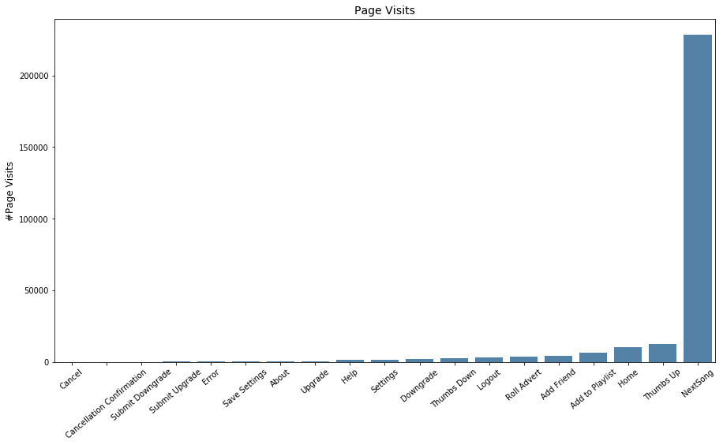

```python
# Page Visits
page_visits_pd = df.groupby('page').count().toPandas().sort_values('count')

# Plot
plt.figure(figsize=(15,8))
sns.barplot(x='page', y='count', data=page_visits_pd, color='steelblue')
plt.title('Page Visits', fontsize=14)
plt.xticks(rotation=40)
plt.xlabel('', fontsize=12)
plt.ylabel('#Page Visits', fontsize=12)
plt.show()
```

```python
# Define "Churn" via user defined function
churn = udf(lambda x: 1 if x == 'Cancellation Confirmation' else 0, IntegerType())
downgrade_churn = udf(lambda x: 1 if x == 'Submit Downgrade' else 0, IntegerType())

# New dataframe with additional columns 'downgraded' and 'cancelled'
df = df.withColumn('downgraded', downgrade_churn('page')).withColumn('cancelled', churn('page'))
```

```python
df.printSchema()
```

```
root
 |-- artist: string (nullable = true)
 |-- auth: string (nullable = true)
 |-- firstName: string (nullable = true)
 |-- gender: string (nullable = true)
 |-- itemInSession: long (nullable = true)
 |-- lastName: string (nullable = true)
 |-- length: double (nullable = true)
 |-- level: string (nullable = true)
 |-- location: string (nullable = true)
 |-- method: string (nullable = true)
 |-- page: string (nullable = true)
 |-- registration: long (nullable = true)
 |-- sessionId: long (nullable = true)
 |-- song: string (nullable = true)
 |-- status: long (nullable = true)
 |-- ts: long (nullable = true)
 |-- userAgent: string (nullable = true)
 |-- userId: string (nullable = true)
 |-- downgraded: integer (nullable = true)
 |-- cancelled: integer (nullable = true)
```

```python
df.select(['userId', 'page', 'downgraded', 'cancelled']).head(5)
```

```
[Row(userId='78', page='NextSong', downgraded=0, cancelled=0),
 Row(userId='78', page='Thumbs Down', downgraded=0, cancelled=0),
 Row(userId='25', page='NextSong', downgraded=0, cancelled=0),
 Row(userId='15', page='NextSong', downgraded=0, cancelled=0),
 Row(userId='27', page='Home', downgraded=0, cancelled=0)]
```

```python
df.select(['userId', 'page', 'downgraded', 'cancelled']).where(df.page == 'Submit Downgrade').head(5)
```

```
[Row(userId='61', page='Submit Downgrade', downgraded=1, cancelled=0),
 Row(userId='200009', page='Submit Downgrade', downgraded=1, cancelled=0),
 Row(userId='95', page='Submit Downgrade', downgraded=1, cancelled=0),
 Row(userId='13', page='Submit Downgrade', downgraded=1, cancelled=0),
 Row(userId='100009', page='Submit Downgrade', downgraded=1, cancelled=0)]
```

```python
df.select(['userId', 'page', 'downgraded', 'cancelled']).where(df.page == 'Cancellation Confirmation').head(5)
```

```
[Row(userId='100022', page='Cancellation Confirmation', downgraded=0, cancelled=1),
 Row(userId='200020', page='Cancellation Confirmation', downgraded=0, cancelled=1),
 Row(userId='28', page='Cancellation Confirmation', downgraded=0, cancelled=1),
 Row(userId='100009', page='Cancellation Confirmation', downgraded=0, cancelled=1),
 Row(userId='100015', page='Cancellation Confirmation', downgraded=0, cancelled=1)]
```

```python
# Show churn statistics
df.select(['userId','downgraded','cancelled']).groupBy('userId').sum()\
    .withColumnRenamed('sum(downgraded)','downgraded')\
    .withColumnRenamed('sum(cancelled)','cancelled').describe().show()
```

```
+-------+------------------+------------------+------------------+
|summary|            userId|        downgraded|         cancelled|
+-------+------------------+------------------+------------------+
|  count|               225|               225|               225|
|   mean|65391.013333333336|              0.28|0.2311111111111111|
| stddev|105396.47791907164|0.5876709477736184|0.4224832108996327|
|    min|                10|                 0|                 0|
|    max|                99|                 3|                 1|
+-------+------------------+------------------+------------------+
```

```python
print('Number of users who downgraded: ' + str(df.filter(df.downgraded == 1).select('userId').dropDuplicates().count()))
print('Number of users who cancelled: ' + str(df.filter(df.cancelled == 1).select('userId').dropDuplicates().count()))
```

```
Number of users who downgraded: 49
Number of users who cancelled: 52
```

```python
# Get hour, day, weekday out of timestamp "ts"
get_hour = udf(lambda x: datetime.datetime.fromtimestamp(x / 1000.0).hour, IntegerType())
get_weekday = udf(lambda x: datetime.datetime.fromtimestamp(x / 1000.0).weekday(), IntegerType())

# Add columns 'hour', 'day', 'weekday' to dataframe
df_sub = df.withColumn("hour", get_hour(df.ts))
df_sub = df_sub.withColumn("weekday", get_weekday(df.ts))
```

```python
df_sub.printSchema()
```

```
root
 |-- artist: string (nullable = true)
 |-- auth: string (nullable = true)
 |-- firstName: string (nullable = true)
 |-- gender: string (nullable = true)
 |-- itemInSession: long (nullable = true)
 |-- lastName: string (nullable = true)
 |-- length: double (nullable = true)
 |-- level: string (nullable = true)
 |-- location: string (nullable = true)
 |-- method: string (nullable = true)
 |-- page: string (nullable = true)
 |-- registration: long (nullable = true)
 |-- sessionId: long (nullable = true)
 |-- song: string (nullable = true)
 |-- status: long (nullable = true)
 |-- ts: long (nullable = true)
 |-- userAgent: string (nullable = true)
 |-- userId: string (nullable = true)
 |-- downgraded: integer (nullable = true)
 |-- cancelled: integer (nullable = true)
 |-- hour: integer (nullable = true)
 |-- weekday: integer (nullable = true)
```

```python
df_sub.select(['userId','ts','hour','weekday']).head(5)
```

```
[Row(userId='78', ts=1538373133000, hour=5, weekday=0),
 Row(userId='78', ts=1538373134000, hour=5, weekday=0),
 Row(userId='25', ts=1538384924000, hour=9, weekday=0),
 Row(userId='15', ts=1538394878000, hour=11, weekday=0),
 Row(userId='27', ts=1538402423000, hour=14, weekday=0)]
```

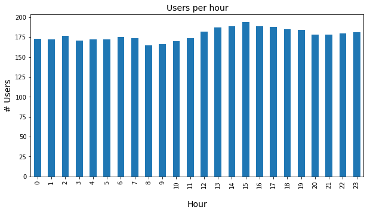

```python
# User distribution per hour of the day
users_per_hour_pd = df_sub.select(['userId','hour']).dropDuplicates().groupby(['hour']).count().sort('hour').toPandas()

# Plot
ax = users_per_hour_pd.plot(x='hour', kind='bar', figsize=(10,5))
ax.get_legend().remove()
plt.xlabel('\nHour', fontsize=14)
plt.ylabel('# Users', fontsize=14)
plt.title('Users per hour', fontsize=14)
plt.show()
```

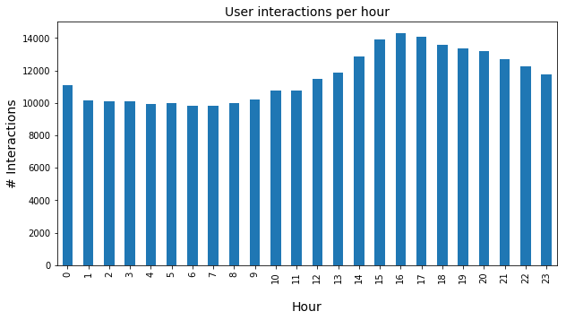

```python
# User interactions per hour
interacts_per_hour_pd = df_sub.select(['userId','hour']).groupby(['hour']).count().sort('hour').toPandas()

# Plot
ax = interacts_per_hour_pd.plot(x='hour', kind='bar', figsize=(10,5))
ax.get_legend().remove()
plt.xlabel('\nHour', fontsize=14)
plt.ylabel('# Interactions', fontsize=14)
plt.title('User interactions per hour', fontsize=14)
plt.show()
```

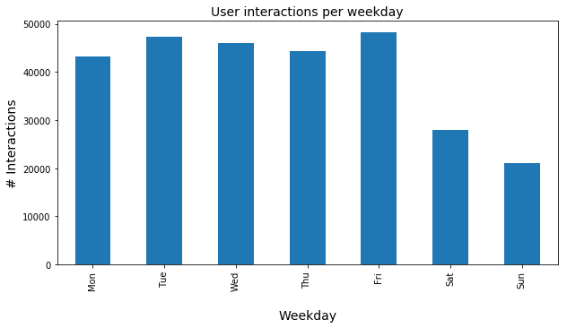

```python
# User interactions per weekday
interacts_per_weekday_pd = df_sub.select(['userId','weekday']).groupby(['weekday']).count().sort('weekday').toPandas()

# Plot
ax = interacts_per_weekday_pd.plot(x='weekday', kind='bar', figsize=(10,5))
ax.get_legend().remove()
plt.xlabel('\nWeekday', fontsize=14)
plt.ylabel('# Interactions', fontsize=14)
plt.title('User interactions per weekday', fontsize=14)
plt.xticks(range(7), ['Mon', 'Tue', 'Wed', 'Thu', 'Fri', 'Sat', 'Sun'])
plt.show()
```

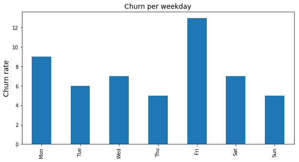

```python
# Churn per weekday
churn_per_weekday_pd = df_sub.select(['userId','weekday','cancelled']).groupby(['weekday']).sum().sort('weekday').toPandas()

# Plot
ax = churn_per_weekday_pd[['weekday','sum(cancelled)']].plot(x='weekday', kind='bar', figsize=(10,5))
ax.get_legend().remove()
plt.xlabel('', fontsize=14)
plt.ylabel('Churn rate', fontsize=14)
plt.title('Churn per weekday', fontsize=14)
plt.xticks(range(7), ['Mon', 'Tue', 'Wed', 'Thu', 'Fri', 'Sat', 'Sun'])
plt.show()
```

```python
# Churn per gender
print('Churner per gender')
df.filter(df.page == 'Cancellation Confirmation').select(['userId', 'gender']).drop_duplicates().groupby('gender').count().show()

print('Non-churner per gender')
df.filter(df.page != 'Cancellation Confirmation').select(['userId', 'gender']).drop_duplicates().groupby('gender').count().show()
```

```
Churner per gender
+------+-----+
|gender|count|
+------+-----+
|     F|   20|
|     M|   32|
+------+-----+

Non-churner per gender
+------+-----+
|gender|count|
+------+-----+
|     F|  104|
|     M|  121|
+------+-----+
```

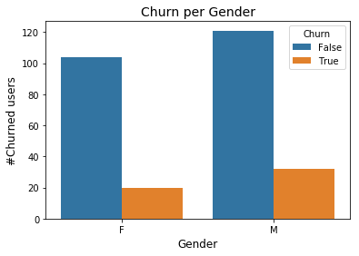

```python
# Churn per gender plot
churn_gender_pd = df.filter(df.page == 'Cancellation Confirmation').select(['userId', 'gender']).drop_duplicates().groupby('gender').count().toPandas()
churn_gender_pd['Churn'] = True
nonchurn_gender_pd = df.filter(df.page != 'Cancellation Confirmation').select(['userId', 'gender']).drop_duplicates().groupby('gender').count().toPandas()
nonchurn_gender_pd['Churn'] = False
churn_gender = pd.concat([churn_gender_pd,nonchurn_gender_pd], sort=False, ignore_index=True)

# Plot
sns.barplot(x='gender', y='count', hue='Churn', data=churn_gender)
plt.xlabel('Gender', fontsize=12)
plt.ylabel('#Churned users', fontsize=12)
plt.title('Churn per Gender', fontsize=14)
plt.show()
```

```python
# Churn per level
print('Churner per level')
df.filter(df.page == 'Cancellation Confirmation').select(['userId', 'level']).drop_duplicates().groupby('level').count().show()

print('Non-churner per level')
df.filter(df.page != 'Cancellation Confirmation').select(['userId', 'level']).drop_duplicates().groupby('level').count().show()
```

```
Churner per level
+-----+-----+
|level|count|
+-----+-----+
| free|   21|
| paid|   31|
+-----+-----+

Non-churner per level
+-----+-----+
|level|count|
+-----+-----+
| free|  195|
| paid|  165|
+-----+-----+
```

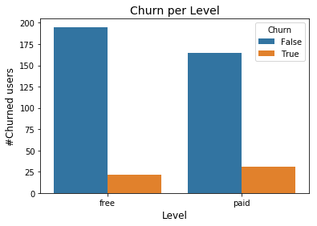

```python
# Churn per level plot
churn_level_pd = df.filter(df.page == 'Cancellation Confirmation').select(['userId', 'level']).drop_duplicates().groupby('level').count().toPandas()
churn_level_pd['Churn'] = True
nonchurn_level_pd = df.filter(df.page != 'Cancellation Confirmation').select(['userId', 'level']).drop_duplicates().groupby('level').count().toPandas()
nonchurn_level_pd['Churn'] = False
churn_level = pd.concat([churn_level_pd,nonchurn_level_pd], sort=False, ignore_index=True)

# Plot
sns.barplot(x='level', y='count', hue='Churn', data=churn_level)
plt.xlabel('Level', fontsize=12)
plt.ylabel('#Churned users', fontsize=12)
plt.title('Churn per Level', fontsize=14)
plt.show()
```

```python
# Churn per device
get_device = udf(lambda x: x.split('(')[1].replace(";", " ").split(" ")[0])
df_devices = df.withColumn('Device', get_device('userAgent'))

print('Churner per device')
df_devices.filter(df.page == 'Cancellation Confirmation').select(['userId', 'Device']).drop_duplicates().groupby('Device').count().show()

print('Non-churner per device')
df_devices.filter(df.page != 'Cancellation Confirmation').select(['userId', 'Device']).drop_duplicates().groupby('Device').count().show()
```

```
Churner per device
+---------+-----+
|   Device|count|
+---------+-----+
|      X11|    5|
|   iPhone|    4|
|Macintosh|   19|
|  Windows|   24|
+---------+-----+

Non-churner per device
+----------+-----+
|    Device|count|
+----------+-----+
|      iPad|    3|
|       X11|   12|
|    iPhone|   13|
| Macintosh|   86|
|compatible|    5|
|   Windows|  106|
+----------+-----+
```

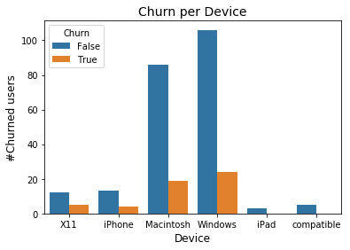

```python
# Churn per device plot
churn_device_pd = df_devices.filter(df_devices.page == 'Cancellation Confirmation').select(['userId', 'Device']).drop_duplicates().groupby('Device').count().toPandas()
churn_device_pd['Churn'] = True
nonchurn_device_pd = df_devices.filter(df_devices.page != 'Cancellation Confirmation').select(['userId', 'Device']).drop_duplicates().groupby('Device').count().toPandas()
nonchurn_device_pd['Churn'] = False
churn_device = pd.concat([churn_device_pd,nonchurn_device_pd], sort=False, ignore_index=True)

# Plot
sns.barplot(x='Device', y='count', hue='Churn', data=churn_device)
plt.xlabel('Device', fontsize=12)
plt.ylabel('#Churned users', fontsize=12)
plt.title('Churn per Device', fontsize=14)
plt.show()
```

# Feature Engineering

Now that we've familiarized ourselves with the data set, we try to find and build promising features to train the model on.

### Feature Creation

The following Features will be creted at user level:

1. avg_session_duration: average session duration [float]
2. churn: "1" for a page cancellation confirmation (defined as churn), "0" for absence of churn [binary]
3. gender: "1" for male, "0" for female [binary]
4. length: total length of songs listened [float]
5. level: latest level of a user. "1" for paid, "0" for free [binary]
6. location: location of the user [binary]
7. page: number visits per page [int]
8. time_since_reg: time since registration [int]
9. sessions: total number of sessions [int]
10. songs: total number of songs listend [int]
11. userAgent: agents used by the user [binary]

```python
# Load small subset for feature engineering
df = spark.read.json('mini_sparkify_event_data.json')

# Drop rows with missing user id
df = df.where(df.userId != '')
```

#### 1. avg_session_duration

```python
# Create Feature
avg_session_duration = df.select(['userId','sessionId','ts']).groupby(['userId','sessionId']).agg(avg('ts').alias('avg_session_duration'))
avg_session_duration = avg_session_duration.drop('sessionId')
avg_session_duration.show(5)
```

```
+------+--------------------+
|userId|avg_session_duration|
+------+--------------------+
|    92|1.538592785972602...|
|    42|1.538685408666666...|
|   101|1.539165263256140...|
|   120|1.539209327272030...|
|   140|1.539424855166666...|
+------+--------------------+
only showing top 5 rows
```

#### 2. churn

```python
# User definded function
get_churn = udf(lambda x: 1 if x == 'Cancellation Confirmation' else 0, IntegerType())

# Create feature
churn = df.withColumn('churn', get_churn('page')).select(['userId','churn']).groupby('userId').agg(max('churn').alias('churn'))
# Validation
print('Number of rows: ' + str(churn.count()))
churn.show(5)
```

```
Number of rows: 225
+------+-----+
|userId|churn|
+------+-----+
|100010|    0|
|200002|    0|
|   125|    1|
|    51|    1|
|   124|    0|
+------+-----+
only showing top 5 rows
```

#### 3. gender

```python
# User definded function
get_gender = udf(lambda x: 1 if x == 'M' else 0, IntegerType())

# Create feature
gender = df.withColumn('gender', get_gender('gender')).select(['userId','gender']).groupby('userId').agg(max('gender').alias('gender'))

# Validation
print('Number of rows: ' + str(gender.count()))
gender.show(5)
```

```
Number of rows: 225
+------+------+
|userId|gender|
+------+------+
|100010|     0|
|200002|     1|
|   125|     1|
|    51|     1|
|   124|     0|
+------+------+
only showing top 5 rows
```

#### 4. length

```python
# Create feature
length = df.select(['userId','length']).groupby('userId').agg(sum('length').alias('length'))

# Validation
print('Number of rows: ' + str(length.count()))
length.show(5)
```

```
Number of rows: 225
+------+------------------+
|userId|            length|
+------+------------------+
|100010| 66940.89735000003|
|200002| 94008.87593999993|
|   125|2089.1131000000005|
|    51| 523275.8428000004|
|   124|1012312.0927899999|
+------+------------------+
only showing top 5 rows
```

#### 5. level

```python
# User definded function
get_level = udf(lambda x: 1 if x == 'paid' else 0, IntegerType())

# Create feature
level = df.select(['userId', 'level', 'ts']).orderBy(desc('ts')).dropDuplicates(['userId']).select(['userId', 'level'])\
        .withColumn('level', get_level('level').cast(IntegerType()))

# Validation
print('Number of rows: ' + str(level.count()))
level.show(5)
```

```
Number of rows: 225
+------+-----+
|userId|level|
+------+-----+
|100010|    0|
|200002|    1|
|   125|    0|
|   124|    1|
|    51|    1|
+------+-----+
only showing top 5 rows
```

#### 6. location

```python
# User definded function
get_location = udf(lambda x: x.split(', ')[1].split('-')[0])
get_location_name = udf(lambda x: "location_"+x.replace(" ", "_").lower())

# Create feature
location = df.withColumn('location', get_location(df['location'])).select(['userId', 'location']).dropDuplicates(['userId'])\
           .groupBy('userId').pivot('location').agg(count('location')).fillna(0)

# Validation
print('Number of rows: ' + str(location.count()))
location.show(5)
```

```
Number of rows: 225
+------+---+---+---+---+---+---+---+---+---+---+---+---+---+---+---+---+---+---+---+---+---+---+---+---+---+---+---+---+---+---+---+---+---+---+---+---+---+---+---+---+---+
|userId| AK| AL| AR| AZ| CA| CO| CT| DC| FL| GA| IA| IL| IN| KY| LA| MA| MD| MI| MN| MO| MS| MT| NC| NE| NH| NJ| NV| NY| OH| OK| OR| PA| RI| SC| TN| TX| UT| VA| WA| WI| WV|
+------+---+---+---+---+---+---+---+---+---+---+---+---+---+---+---+---+---+---+---+---+---+---+---+---+---+---+---+---+---+---+---+---+---+---+---+---+---+---+---+---+---+
|100010|  0|  0|  0|  0|  0|  0|  1|  0|  0|  0|  0|  0|  0|  0|  0|  0|  0|  0|  0|  0|  0|  0|  0|  0|  0|  0|  0|  0|  0|  0|  0|  0|  0|  0|  0|  0|  0|  0|  0|  0|  0|
|200002|  0|  0|  0|  0|  0|  0|  0|  0|  0|  0|  0|  1|  0|  0|  0|  0|  0|  0|  0|  0|  0|  0|  0|  0|  0|  0|  0|  0|  0|  0|  0|  0|  0|  0|  0|  0|  0|  0|  0|  0|  0|
|   125|  0|  0|  0|  0|  0|  0|  0|  0|  0|  0|  0|  0|  0|  0|  0|  0|  0|  0|  0|  0|  0|  0|  0|  0|  0|  0|  0|  0|  0|  0|  0|  0|  0|  0|  0|  1|  0|  0|  0|  0|  0|
|   124|  0|  0|  0|  0|  0|  0|  0|  0|  0|  0|  0|  0|  0|  0|  0|  0|  0|  0|  0|  0|  0|  0|  0|  0|  0|  1|  0|  0|  0|  0|  0|  0|  0|  0|  0|  0|  0|  0|  0|  0|  0|
|    51|  0|  0|  0|  0|  0|  0|  0|  0|  0|  0|  0|  0|  0|  1|  0|  0|  0|  0|  0|  0|  0|  0|  0|  0|  0|  0|  0|  0|  0|  0|  0|  0|  0|  0|  0|  0|  0|  0|  0|  0|  0|
+------+---+---+---+---+---+---+---+---+---+---+---+---+---+---+---+---+---+---+---+---+---+---+---+---+---+---+---+---+---+---+---+---+---+---+---+---+---+---+---+---+---+
only showing top 5 rows
```

#### 7. page

```python
# User definded function
get_page = udf(lambda x: 'page_' + x.replace(' ', '_').lower())
exclude_page = ['Cancel', 'Cancellation Confirmation']

# Create feature
page = df.filter(~df['page'].isin(exclude_page)).withColumn('page', get_page(df['page']))\
                 .groupBy(['userId']).pivot('page').agg(count('page')).fillna(0)

# Validation
print('Number of rows: ' + str(page.count()))
page.show(5)
```

```
Number of rows: 225
+------+----------+---------------+--------------------+--------------+----------+---------+---------+-----------+-------------+----------------+------------------+-------------+---------------------+-------------------+----------------+--------------+------------+
|userId|page_about|page_add_friend|page_add_to_playlist|page_downgrade|page_error|page_help|page_home|page_logout|page_nextsong|page_roll_advert|page_save_settings|page_settings|page_submit_downgrade|page_submit_upgrade|page_thumbs_down|page_thumbs_up|page_upgrade|
+------+----------+---------------+--------------------+--------------+----------+---------+---------+-----------+-------------+----------------+------------------+-------------+---------------------+-------------------+----------------+--------------+------------+
|200002|         3|              4|                   8|             5|         0|        2|       20|          5|          387|               7|                 0|            3|                    0|                  1|               6|            21|           2|
|100010|         1|              4|                   7|             0|         0|        2|       11|          5|          275|              52|                 0|            0|                    0|                  0|               5|            17|           2|
|   125|         0|              0|                   0|             0|         0|        0|        0|          0|            8|               1|                 0|            0|                    0|                  0|               0|             0|           0|
|     7|         0|              1|                   5|             0|         1|        1|       10|          3|          150|              16|                 1|            3|                    0|                  0|               1|             7|           2|
|   124|         7|             74|                 118|            41|         6|       23|      176|         59|         4079|               4|                 6|           20|                    0|                  0|              41|           171|           0|
+------+----------+---------------+--------------------+--------------+----------+---------+---------+-----------+-------------+----------------+------------------+-------------+---------------------+-------------------+----------------+--------------+------------+
only showing top 5 rows
```

#### 8. time_since_reg

```python
# Create feature
df_reg_ts = df.select(['userId','registration']).groupby('userId').agg(min('registration').alias('reg_ts'))
df_max_ts = df.select(['userId','ts']).groupby('userId').agg(max('ts').alias('max_ts'))
time_since_reg = df_max_ts.join(df_reg_ts, on=['userId'])

# Calculate Delta
time_since_reg = time_since_reg.withColumn('time_since_reg', expr('max_ts - reg_ts'))
time_since_reg = time_since_reg.drop('max_ts')
time_since_reg = time_since_reg.drop('reg_ts')

# Validation
print('Number of rows: ' + str(time_since_reg.count()))
time_since_reg.show(5)
```

```
Number of rows: 225
+------+--------------+
|userId|time_since_reg|
+------+--------------+
|100010|    4807612000|
|200002|    6054448000|
|   125|    6161779000|
|   124|   11366431000|
|    51|    1680985000|
+------+--------------+
only showing top 5 rows
```

#### 9. sessions

```python
# Create feature
sessions = df.select(['userId','sessionId']).dropDuplicates().groupby('userId').agg(count('sessionId').alias('sessions'))

# Validation
print('Number of rows: ' + str(sessions.count()))
sessions.show(5)
```

```
Number of rows: 225
+------+--------+
|userId|sessions|
+------+--------+
|100010|       7|
|200002|       6|
|   125|       1|
|    51|      10|
|   124|      29|
+------+--------+
only showing top 5 rows
```

#### 10. songs

```python
# Create feature
songs = df.select(['userId','song']).groupby('userId').agg(count('song').alias('songs'))

# Validation
print('Number of rows: ' + str(songs.count()))
songs.show(5)
```

```
Number of rows: 225
+------+-----+
|userId|songs|
+------+-----+
|100010|  275|
|200002|  387|
|   125|    8|
|    51| 2111|
|   124| 4079|
+------+-----+
only showing top 5 rows
```

#### 11. userAgent

```python
# User definded function
get_agent = udf(lambda x: x.split('(')[1].replace(";", " ").split(" ")[0])

# Create feature
userAgent = df.withColumn('userAgent', get_agent(df['userAgent'])).select(['userId', 'userAgent']).dropDuplicates(['userId'])\
            .groupBy('userId').pivot('userAgent').agg(count('userAgent')).fillna(0)

# Validation
print('Number of rows: ' + str(userAgent.count()))
userAgent.show(5)
```

```
Number of rows: 225
+------+---------+-------+---+----------+----+------+
|userId|Macintosh|Windows|X11|compatible|iPad|iPhone|
+------+---------+-------+---+----------+----+------+
|100010|        0|      0|  0|         0|   0|     1|
|200002|        0|      0|  0|         0|   0|     1|
|   125|        1|      0|  0|         0|   0|     0|
|   124|        1|      0|  0|         0|   0|     0|
|    51|        0|      1|  0|         0|   0|     0|
+------+---------+-------+---+----------+----+------+
only showing top 5 rows
```

### Merge Features

Bring together all built features.

```python
df = churn.join(avg_session_duration, ['userId'])\
          .join(gender, ['userId'])\
          .join(length, ['userId'])\
          .join(level, ['userId'])\
          .join(location, ['userId'])\
          .join(page, ['userId'])\
          .join(time_since_reg, ['userId'])\
          .join(sessions, ['userId'])\
          .join(songs, ['userId'])\
          .join(userAgent, ['userId'])
```

```python
df.printSchema()
```

```
root
 |-- userId: string (nullable = true)
 |-- churn: integer (nullable = true)
 |-- avg_session_duration: double (nullable = true)
 |-- gender: integer (nullable = true)
 |-- length: double (nullable = true)
 |-- level: integer (nullable = true)
 |-- AK: long (nullable = true)
 |-- AL: long (nullable = true)
 |-- AR: long (nullable = true)
 |-- AZ: long (nullable = true)
 |-- CA: long (nullable = true)
 |-- CO: long (nullable = true)
 |-- CT: long (nullable = true)
 |-- DC: long (nullable = true)
 |-- FL: long (nullable = true)
 |-- GA: long (nullable = true)
 |-- IA: long (nullable = true)
 |-- IL: long (nullable = true)
 |-- IN: long (nullable = true)
 |-- KY: long (nullable = true)
 |-- LA: long (nullable = true)
 |-- MA: long (nullable = true)
 |-- MD: long (nullable = true)
 |-- MI: long (nullable = true)
 |-- MN: long (nullable = true)
 |-- MO: long (nullable = true)
 |-- MS: long (nullable = true)
 |-- MT: long (nullable = true)
 |-- NC: long (nullable = true)
 |-- NE: long (nullable = true)
 |-- NH: long (nullable = true)
 |-- NJ: long (nullable = true)
 |-- NV: long (nullable = true)
 |-- NY: long (nullable = true)
 |-- OH: long (nullable = true)
 |-- OK: long (nullable = true)
 |-- OR: long (nullable = true)
 |-- PA: long (nullable = true)
 |-- RI: long (nullable = true)
```

[output cut: 19 more lines]

```
 |-- page_settings: long (nullable = true)
 |-- page_submit_downgrade: long (nullable = true)
 |-- page_submit_upgrade: long (nullable = true)
 |-- page_thumbs_down: long (nullable = true)
 |-- page_thumbs_up: long (nullable = true)
 |-- page_upgrade: long (nullable = true)
 |-- time_since_reg: long (nullable = true)
 |-- sessions: long (nullable = false)
 |-- songs: long (nullable = false)
 |-- Macintosh: long (nullable = true)
 |-- Windows: long (nullable = true)
 |-- X11: long (nullable = true)
 |-- compatible: long (nullable = true)
 |-- iPad: long (nullable = true)
 |-- iPhone: long (nullable = true)
```

### Check for Multicollinearity

Check, if a feature is correlated to other features and removal of highly correlated features.

```python
# Convert df to Pandas df
df_pd = df.toPandas()
```

```python
# Correlation matrix
correlation_matrix = df_pd.corr('pearson')

# Too many features to visualize the matrix, so iterate rows and drop highly correlated rows
correlated_columns = []
for column in correlation_matrix.columns:
    correlated = correlation_matrix.drop(column, axis=0).loc[correlation_matrix[column].abs()>=0.5].index.tolist()
    if len(correlated) > 0:
        correlated_columns.append(column)

# Show corelated columns
correlated_columns
```

```
['length',
 'MA',
 'page_about',
 'page_add_friend',
 'page_add_to_playlist',
 'page_downgrade',
 'page_error',
 'page_help',
 'page_home',
 'page_logout',
 'page_nextsong',
 'page_roll_advert',
 'page_save_settings',
 'page_settings',
 'page_submit_downgrade',
 'page_submit_upgrade',
 'page_thumbs_down',
 'page_thumbs_up',
 'page_upgrade',
 'sessions',
 'songs',
 'Macintosh',
 'Windows',
 'iPad']
```

```python
# Identify features that higly correlate with any other feature
max_corr = 0.85 # Set parameter for maximum permitted pearson correlation coefficient

# Loop over columns
highly_correlated_columns = []
counter = 0
for column in correlated_columns:
    if (column != 'churn') & (correlation_matrix[column].drop(column).max() > max_corr):
        counter += 1
        print(str(counter) + '. ' + str(column))
        highly_correlated_columns.append(column)

print('\n{} highly correlated features (Pearson Correlation Coeffitient larger than {}) to drop.'.format(counter,max_corr))
```

```
1. length
2. page_add_friend
3. page_add_to_playlist
4. page_downgrade
5. page_help
6. page_home
7. page_logout
8. page_nextsong
9. page_settings
10. page_thumbs_down
11. page_thumbs_up
12. sessions
13. songs

13 highly correlated features (Pearson Correlation Coeffitient larger than 0.85) to drop.
```

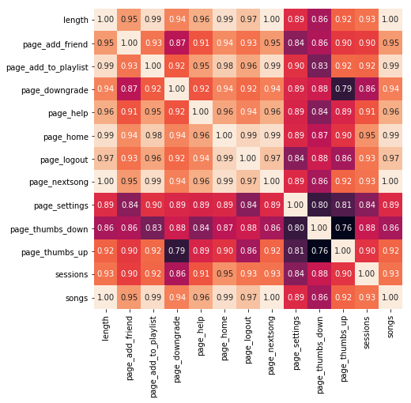

```python
# Inspect highly correlated features
correlation_matrix_sub = df_pd[highly_correlated_columns].corr('pearson')

# Plot correlation matrix
ax = plt.subplots(figsize=(7, 7))
ax = sns.heatmap(correlation_matrix_sub, annot = True, fmt = '.2f', cbar=False)
plt.show()
```

```python
# Drop features that higly correlate with any other feature
df_pd.drop(highly_correlated_columns, axis=1, inplace=True)
```

```python
# Store names of features to keep for further analysis
features_to_keep = list(df_pd.columns)
print(features_to_keep)
```

```
['userId', 'churn', 'avg_session_duration', 'gender', 'level', 'AK', 'AL', 'AR', 'AZ', 'CA', 'CO', 'CT', 'DC', 'FL', 'GA', 'IA', 'IL', 'IN', 'KY', 'LA', 'MA', 'MD', 'MI', 'MN', 'MO', 'MS', 'MT', 'NC', 'NE', 'NH', 'NJ', 'NV', 'NY', 'OH', 'OK', 'OR', 'PA', 'RI', 'SC', 'TN', 'TX', 'UT', 'VA', 'WA', 'WI…
```

```python
# Select features to keep for further analysis from raw data and build a new Spark dataframe
df = df.select(features_to_keep)

# Convert to pandas
df_pd = df.toPandas()

# Print columns
df_pd.columns
```

```
Index(['userId', 'churn', 'avg_session_duration', 'gender', 'level', 'AK',
       'AL', 'AR', 'AZ', 'CA', 'CO', 'CT', 'DC', 'FL', 'GA', 'IA', 'IL', 'IN',
       'KY', 'LA', 'MA', 'MD', 'MI', 'MN', 'MO', 'MS', 'MT', 'NC', 'NE', 'NH',
       'NJ', 'NV', 'NY', 'OH', 'OK', 'OR', 'PA', 'RI', 'SC', 'TN', 'TX', 'UT',
       'VA', 'WA', 'WI', 'WV', 'page_about', 'page_error', 'page_roll_advert',
       'page_save_settings', 'page_submit_downgrade', 'page_submit_upgrade',
       'page_upgrade', 'time_since_reg', 'Macintosh', 'Windows', 'X11',
       'compatible', 'iPad', 'iPhone'],
      dtype='object')
```

```python
# Check for missing values
missings = df_pd.isnull().sum().sum()
print('Number of missing values: {}'.format(missings))
```

```
Number of missing values: 0
```

### Feature Scaling

The range of values in a feature should reflect their importance. Higher values imply higher importances. Some features might have larger values than others and are required to be transformed for equal importance. Rule of thumb I follow here is any algorithm that computes distances or assumes normality, feature scaling is required. Below I show two common methods for this so-called step of "feature scaling": 1.) Normalization and 2.) Standardization.

#### 1. Normalization

Normalize numerical features to range [0,1] e.g. via min-max normalization: Normalised Value = (Value - Feature Min)/(Feature Max - Feature Min)

#### 2. Standardization

The Central Limit Theorem guarantees that the average of independent random variables is approximately normally distributed even when the individual random variables are not normally distributed. By standardization you ensure the values in a feature follow the normal distribution whereby mean of the values is 0 and standard deviation is 1. Standarderised Value = (Value - Feature Mean)/Feature Standard Deviation

Let's take a look on the distribution of all numerical, non-binary features:

```python
# Distribution of all numerical, non-binary features
num_features = ['avg_session_duration', 'page_about', 'page_error', 'page_roll_advert', 'page_save_settings',
                'page_submit_downgrade', 'page_submit_upgrade', 'page_upgrade', 'time_since_reg']
```

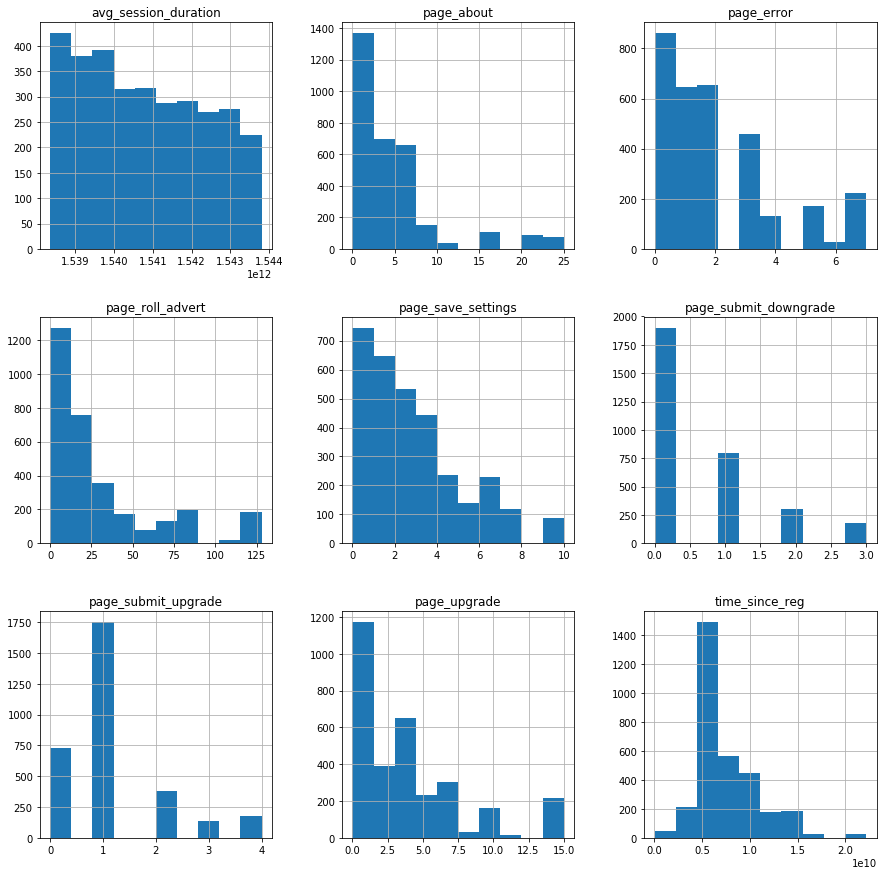

```python
df_pd[num_features].hist(figsize=(15,15))
plt.show()
```

Most of the numerical features are skewed. I decide to perform a feature standardization so that they are closer to normal distribution. To implement any of the options to do feature transformations in Spark to standardize or normalize the data, we need to assemble the features into a feature vector. This is done by Spark's Vector Assembler:

```python
# Vectorize features
assembler = VectorAssembler(inputCols=num_features, outputCol='FeatureVector')
df_assembled = assembler.transform(df)
```

```python
# Standardize features
scaler = StandardScaler(inputCol='FeatureVector', outputCol='ScaledNumFeatures', withStd=True)
scalerModel = scaler.fit(df_assembled)
df_scaled = scalerModel.transform(df_assembled)
```

```python
df_scaled.head()
```

```
Row(userId='100010', churn=0, avg_session_duration=1541741825357.1428, gender=0, level=0, AK=0, AL=0, AR=0, AZ=0, CA=0, CO=0, CT=1, DC=0, FL=0, GA=0, IA=0, IL=0, IN=0, KY=0, LA=0, MA=0, MD=0, MI=0, MN=0, MO=0, MS=0, MT=0, NC=0, NE=0, NH=0, NJ=0, NV=0, NY=0, OH=0, OK=0, OR=0, PA=0, RI=0, SC=0, TN=0, …
```

Subsequent remark: In the modeling part I have seen that it's more practical to use Min-Max Normalization instead of standardization, beacuase the dataset contains numerical and dummy variables.

# Modeling

### Train-Test Split

```python
# Train-test-validation split
train_set, rest = df_scaled.drop('userId').randomSplit([0.8, 0.2], seed=42)
validation_set, test_set = rest.randomSplit([0.1,0.1], seed=42)
```

### Metrics

Due to the fact that our dataset is imbalanced (23% churn, 77% non-churn), using accuracy as metric would be missleading. Instead I will use F1 score as evaluation metric. It considers both the precision p and the recall r to compute the score: p is the number of correct positive results divided by the number of all positive results returned by the classifier, and r is the number of correct positive results divided by the number of all relevant samples (all samples that should have been identified as positive). The F1 score is the harmonic average of the precision and recall, where an F1 score reaches its best value at 1 (perfect precision and recall) and worst at 0.

source: https://en.wikipedia.org/wiki/F1_score

### Functions & Machine Learning Pipeline

At next I will train a couple of classification algorithms on the training data, test their prediction performance on the test data and chose the best performing one for my Spark implementation. I will try out the following classification algrithms: Decision Tree, Random Forest, Gradient Boosting and Logistic Regression. I will build a pipeline containing the following steps:

- Load Data
- Create Features
- Feature Scaling
- Train-Test Split
- Cross Validation
- Training of Machine Learning Model
- Evaluation of Prediction Performance

```python
def load_data(path):
    '''
    Load a data set that is stored under a given path. Rows with missing ids will be removed.

    INPUT
    - path: Path where the data is stored

    OUTPUT
    - df: Dataframe
    '''

    # Load small subset for feature engineering
    df = spark.read.json(path)

    # Drop rows with missing user id
    df = df.where(df.userId != '')

    return df
```

```python
def feature_creation(df):
    '''
    The following Features will be creted at user level:

    1.  avg_session_duration: average session duration [float]
    2.  churn: "1" for a page cancellation confirmation (defined as churn), "0" for absence of churn [binary]
    3.  gender: "1" for male, "0" for female [binary]
    4.  length: total length of songs listened [float]
    5.  level: latest level of a user. "1" for paid, "0" for free [binary]
    6.  location: location of the user [binary]
    7.  page: number visits per page [int]
    8.  time_since_reg: time since registration [int]
    9.  sessions: total number of sessions [int]
    10. songs: total number of songs listend [int]
    11. userAgent: agents used by the user [binary]

    Afterwards, all features are joined, checked for multicollinearity and strongly correlating features will be removed.

    INPUT
    - path: Path where the data is stored

    OUTPUT
    - df: Dataframe
    '''

    # 1.  avg_session_duration
    avg_session_duration = df.select(['userId','sessionId','ts']).groupby(['userId','sessionId'])\
                                     .agg(avg('ts').alias('avg_session_duration'))
    avg_session_duration = avg_session_duration.drop('sessionId')

    # 2.  churn
    get_churn = udf(lambda x: 1 if x == 'Cancellation Confirmation' else 0, IntegerType())
    churn = df.withColumn('churn', get_churn('page')).select(['userId','churn'])\
                          .groupby('userId').agg(max('churn').alias('churn'))

    # 3.  gender
    get_gender = udf(lambda x: 1 if x == 'M' else 0, IntegerType())
    gender = df.withColumn('gender', get_gender('gender')).select(['userId','gender'])\
                           .groupby('userId').agg(max('gender').alias('gender'))


    # 4.  length
    length = df.select(['userId','length']).groupby('userId').agg(sum('length').alias('length'))

    # 5.  level
    get_level = udf(lambda x: 1 if x == 'paid' else 0, IntegerType())
    level = df.select(['userId', 'level', 'ts']).orderBy(desc('ts')).dropDuplicates(['userId']).select(['userId', 'level'])\
                      .withColumn('level', get_level('level').cast(IntegerType()))

    # 6.  location
    get_location = udf(lambda x: x.split(', ')[1].split('-')[0])
    get_location_name = udf(lambda x: "location_"+x.replace(" ", "_").lower())
    location = df.withColumn('location', get_location(df['location'])).select(['userId', 'location'])\
                             .dropDuplicates(['userId']).groupBy('userId').pivot('location').agg(count('location')).fillna(0)

    # 7.  page
    get_page = udf(lambda x: 'page_' + x.replace(' ', '_').lower())
    exclude_page = ['Cancel', 'Cancellation Confirmation']
    page = df.filter(~df['page'].isin(exclude_page)).withColumn('page', get_page(df['page']))\
                     .groupBy(['userId']).pivot('page').agg(count('page')).fillna(0)

    # 8.  time_since_reg
    df_reg_ts = df.select(['userId','registration']).groupby('userId').agg(min('registration').alias('reg_ts'))
    df_max_ts = df.select(['userId','ts']).groupby('userId').agg(max('ts').alias('max_ts'))
    time_since_reg = df_max_ts.join(df_reg_ts, on=['userId'])
    time_since_reg = time_since_reg.withColumn('time_since_reg', expr('max_ts - reg_ts'))
    time_since_reg = time_since_reg.drop('max_ts')
    time_since_reg = time_since_reg.drop('reg_ts')

    # 9.  sessions
    sessions = df.select(['userId','sessionId']).dropDuplicates().groupby('userId').agg(count('sessionId').alias('sessions'))

    # 10. songs
    songs = df.select(['userId','song']).groupby('userId').agg(count('song').alias('songs'))

    # 11. userAgent
    get_agent = udf(lambda x: x.split('(')[1].replace(";", " ").split(" ")[0])
    userAgent = df.withColumn('userAgent', get_agent(df['userAgent'])).select(['userId', 'userAgent'])\
                              .dropDuplicates(['userId']).groupBy('userId').pivot('userAgent').agg(count('userAgent')).fillna(0)

    # Bringing all together
    df = churn.join(avg_session_duration, ['userId'])\
          .join(gender, ['userId'])\
          .join(length, ['userId'])\
          .join(level, ['userId'])\
          .join(location, ['userId'])\
          .join(page, ['userId'])\
          .join(time_since_reg, ['userId'])\
          .join(sessions, ['userId'])\
          .join(songs, ['userId'])\
          .join(userAgent, ['userId'])

    # Check for multicollinearity
    df_pd = df.toPandas()
    correlation_matrix = df_pd.corr('pearson') # Correlation matrix
    correlated_columns = []
    for column in correlation_matrix.columns: # Iterate rows and drop highly correlated rows
        correlated = correlation_matrix.drop(column, axis=0).loc[correlation_matrix[column].abs()>=0.5].index.tolist()
        if len(correlated) > 0:
            correlated_columns.append(column)

    # Drop features that higly correlate with any other feature
    df_pd.drop(highly_correlated_columns, axis=1, inplace=True)
    features_to_keep = list(df_pd.columns)
    df = df.select(features_to_keep)

    # Check for missing values
    df_pd = df.toPandas()
    missings = df_pd.isnull().sum().sum()
    print('Number of missing values: {}'.format(missings))

    return df
```

```python
def feature_scaling(df):
    '''
    Perform feature standardization on a set of given data to ensure the values in a feature follow the
    normal distribution whereby mean of the values is 0 and standard deviation is 1.

    INPUT
    - df: PySpark Dataframe

    OUTPUT
    - scaled_df: PySpark Dataframe with standardized features
    '''

    # Get features without ids and labels
    feature_cols = df.drop('userId', 'churn').columns
    print(str(len(feature_cols)) + ' Features for Scaling:\n')
    print(feature_cols)

    # Vector assembler
    assembler = VectorAssembler(inputCols=feature_cols, outputCol='FeatureVector')

    # PySpark.ML expects the target column to be named as 'labelCol' af data type double
    df = df.withColumn('label', df['churn'].cast('float')).drop('churn')

    # Feature scaler
    #scaler = StandardScaler(inputCol='FeatureVector', outputCol='ScaledFeatures', withStd=True)
    scaler = MinMaxScaler(inputCol='FeatureVector', outputCol='ScaledFeatures')

    # Perform assembling and standardizing of features
    df = assembler.transform(df)
    scalerModel = scaler.fit(df)
    scaled_df = scalerModel.transform(df)

    # Visulize example row
    print('\nExample row of scaled features:\n')
    print(scaled_df.head(1))

    # Just take scaled feature vector and labels
    scaled_df = scaled_df.select('ScaledFeatures', 'label')
    print('\nReduced to scaled feature vector and labels:\n')
    print(scaled_df.printSchema())
    print(scaled_df.head(1))

    return scaled_df
```

```python
# Testing of feature scaling function
test_df = feature_scaling(df)
```

```
58 Features for Scaling:

['avg_session_duration', 'gender', 'level', 'AK', 'AL', 'AR', 'AZ', 'CA', 'CO', 'CT', 'DC', 'FL', 'GA', 'IA', 'IL', 'IN', 'KY', 'LA', 'MA', 'MD', 'MI', 'MN', 'MO', 'MS', 'MT', 'NC', 'NE', 'NH', 'NJ', 'NV', 'NY', 'OH', 'OK', 'OR', 'PA', 'RI', 'SC', 'TN', 'TX', 'UT', 'VA', 'WA', 'WI', 'WV', 'page_abou…

Example row of scaled features:

[Row(userId='100010', avg_session_duration=1541741825357.1428, gender=0, level=0, AK=0, AL=0, AR=0, AZ=0, CA=0, CO=0, CT=1, DC=0, FL=0, GA=0, IA=0, IL=0, IN=0, KY=0, LA=0, MA=0, MD=0, MI=0, MN=0, MO=0, MS=0, MT=0, NC=0, NE=0, NH=0, NJ=0, NV=0, NY=0, OH=0, OK=0, OR=0, PA=0, RI=0, SC=0, TN=0, TX=0, UT…

Reduced to scaled feature vector and labels:

root
 |-- ScaledFeatures: vector (nullable = true)
 |-- label: float (nullable = true)

None
[Row(ScaledFeatures=DenseVector([0.6221, 0.0, 0.0, 0.0, 0.0, 0.0, 0.0, 0.0, 0.0, 1.0, 0.0, 0.0, 0.0, 0.0, 0.0, 0.0, 0.0, 0.0, 0.0, 0.0, 0.0, 0.0, 0.0, 0.0, 0.0, 0.0, 0.0, 0.0, 0.0, 0.0, 0.0, 0.0, 0.0, 0.0, 0.0, 0.0, 0.0, 0.0, 0.0, 0.0, 0.0, 0.0, 0.0, 0.0, 0.04, 0.0, 0.4062, 0.0, 0.0, 0.0, 0.1333, 0.…
```

```python
def train_test_split(scaled_df):
    '''
    Split the data into training set and test set.

    INPUT
    - df: Scaled PySpark Dataframe

    OUTPUT
    - train_set: training set
    - test_set: test set
    '''

    # Train-test-validation split
    train_set, test_set = scaled_df.drop('userId').randomSplit([0.8, 0.2], seed=42)

    return train_set, test_set
```

```python
# Testing of train-test split function
train_set, test_set = train_test_split(test_df)
print('Visualization of one train set row:\n')
print(train_set.head(1))

print('\n--------------------------------')
print('Size of whole data set: ' + str(test_df.count()))
print('--------------------------------')
print('Size of train set: ' + str(train_set.count()))
print('Size of test set: ' + str(test_set.count()))
print('--------------------------------')
```

```
Visualization of one train set row:

[Row(ScaledFeatures=DenseVector([0.0072, 1.0, 1.0, 0.0, 0.0, 0.0, 0.0, 0.0, 0.0, 0.0, 0.0, 0.0, 0.0, 0.0, 1.0, 0.0, 0.0, 0.0, 0.0, 0.0, 0.0, 0.0, 0.0, 0.0, 0.0, 0.0, 0.0, 0.0, 0.0, 0.0, 0.0, 0.0, 0.0, 0.0, 0.0, 0.0, 0.0, 0.0, 0.0, 0.0, 0.0, 0.0, 0.0, 0.0, 0.12, 0.0, 0.0547, 0.0, 0.0, 0.25, 0.1333, 0…

--------------------------------
Size of whole data set: 3176
--------------------------------
Size of train set: 2533
Size of test set: 643
--------------------------------
```

```python
def cross_validation(classifier, parameter_grid):
    '''
    Performs Cross validation
    Cross validation is a technique for estimating the performance of a predictive model

    INPUT
    - classifier: untrained classifier
    - parameter_grid: a grid of parameters

    OUTPUT
    - crossval: cross validator
    '''

    crossval = CrossValidator(estimator = classifier,
                              estimatorParamMaps = parameter_grid,
                              evaluator = MulticlassClassificationEvaluator(metricName='f1'),
                              numFolds = 3)

    return crossval
```

```python
def train_model(classifier, train_set, parameter_grid):
    '''
    Training of classification model

    INPUT
    - classifier: untrained classifier
    - train_set: training data
    - parameter_grid: a grid of parameters

    OUTPUT
    - model: trained classifier
    '''

    # Cross validation
    crossval = cross_validation(classifier, parameter_grid)

    # Train model
    model = crossval.fit(train_set)

    return model
```

```python
def evaluate_model(classifier, data):
    '''
    Evaluation of trained classification model

    INPUT
    - classifier: trained classifier
    - data: evaluation data

    OUTPUT
    - metrics : Disctionary of evaluation metrics
    '''

    # Predict
    predictions = classifier.transform(data)

    # Evaluator
    evaluator = MulticlassClassificationEvaluator(predictionCol='prediction', labelCol='label')

    # Calculate metrics
    metrics = {}
    metrics['precision'] = evaluator.evaluate(predictions, {evaluator.metricName: 'weightedPrecision'})
    metrics['recall'] = evaluator.evaluate(predictions, {evaluator.metricName: 'weightedRecall'})
    metrics['f1'] = evaluator.evaluate(predictions, {evaluator.metricName: 'f1'})
    metrics['accuracy'] = evaluator.evaluate(predictions, {evaluator.metricName: 'accuracy'})
    metrics['confusion_matrix'] = predictions.groupby('label').pivot('prediction').count()

    return metrics
```

```python
def ml_pipeline(model, path):
    '''
    Machine Learning pipeline that brings all steps together:
    1. Load data
    2. Feature creation
    3. Feature Scaling
    4. Train-Test Split
    5. Build model
    6. Cross validation
    7. Model training
    8. Model evaluation

    INPUT
    - model: classification model to build
    - train_set: training data
    - test_set: test data

    OUTPUT
    - trained_classifier: trained model
    '''
    print('\nModel: ' + model + '\n')

    print('----------------------------')
    print('1. Load Data')
    print('----------------------------')

    df = load_data(path)

    print('----------------------------')
    print('2. Feature Creation')
    print('----------------------------')

    df = feature_creation(df)

    print('----------------------------')
    print('3. Feature Scaling')
    print('----------------------------')

    scaled_df = feature_scaling(df)

    print('----------------------------')
    print('4. Train-Test Split')
    print('----------------------------')

    train_set, test_set = train_test_split(scaled_df)

    print('----------------------------')
    print('5. Build model')
    print('----------------------------')

    if model == 'Decision Tree':
        classifier = DecisionTreeClassifier(labelCol='label', featuresCol='ScaledFeatures')
        file_name = 'cv_dtree_cf.model'
    if model == 'Random Forest':
        classifier = RandomForestClassifier(labelCol='label', featuresCol='ScaledFeatures')
        file_name = 'cv_randomforest_cf.model'
    if model == 'Logistic Regression':
        classifier = LogisticRegression(labelCol='label', featuresCol='ScaledFeatures')
        file_name = 'cv_logreg_cf.model'
    if model == 'Gradient Boosting':
        classifier = GBTClassifier(labelCol='label', featuresCol='ScaledFeatures')
        file_name = 'cv_gradientboo_cf.model'

    print('----------------------------')
    print('6. & 7. Cross Val. & Training')
    print('----------------------------')

    parameter_grid = ParamGridBuilder().build()
    trained_classifier = train_model(classifier, train_set, parameter_grid)

    # Get best model
    bestModel = trained_classifier.bestModel

    # Save trained model
    bestModel.write().overwrite().save(file_name)

    print('----------------------------')
    print('8. Model Evaluation')
    print('----------------------------')

    metrics = evaluate_model(trained_classifier, test_set)
    print(metrics)

    return trained_classifier
```

```python
# 1. Model: Random Forest Classifier
cv_randomforest_cf = ml_pipeline('Random Forest', 'mini_sparkify_event_data.json')
```

```
Model: Random Forest

----------------------------
1. Load Data
----------------------------
----------------------------
2. Feature Creation
----------------------------
Number of missing values: 0
----------------------------
3. Feature Scaling
----------------------------
58 Features for Scaling:

['avg_session_duration', 'gender', 'level', 'AK', 'AL', 'AR', 'AZ', 'CA', 'CO', 'CT', 'DC', 'FL', 'GA', 'IA', 'IL', 'IN', 'KY', 'LA', 'MA', 'MD', 'MI', 'MN', 'MO', 'MS', 'MT', 'NC', 'NE', 'NH', 'NJ', 'NV', 'NY', 'OH', 'OK', 'OR', 'PA', 'RI', 'SC', 'TN', 'TX', 'UT', 'VA', 'WA', 'WI', 'WV', 'page_abou…

Example row of scaled features:

[Row(userId='100010', avg_session_duration=1541741825357.1428, gender=0, level=0, AK=0, AL=0, AR=0, AZ=0, CA=0, CO=0, CT=1, DC=0, FL=0, GA=0, IA=0, IL=0, IN=0, KY=0, LA=0, MA=0, MD=0, MI=0, MN=0, MO=0, MS=0, MT=0, NC=0, NE=0, NH=0, NJ=0, NV=0, NY=0, OH=0, OK=0, OR=0, PA=0, RI=0, SC=0, TN=0, TX=0, UT…

Reduced to scaled feature vector and labels:

root
 |-- ScaledFeatures: vector (nullable = true)
 |-- label: float (nullable = true)

None
[Row(ScaledFeatures=DenseVector([0.6221, 0.0, 0.0, 0.0, 0.0, 0.0, 0.0, 0.0, 0.0, 1.0, 0.0, 0.0, 0.0, 0.0, 0.0, 0.0, 0.0, 0.0, 0.0, 0.0, 0.0, 0.0, 0.0, 0.0, 0.0, 0.0, 0.0, 0.0, 0.0, 0.0, 0.0, 0.0, 0.0, 0.0, 0.0, 0.0, 0.0, 0.0, 0.0, 0.0, 0.0, 0.0, 0.0, 0.0, 0.04, 0.0, 0.4062, 0.0, 0.0, 0.0, 0.1333, 0.…
----------------------------
4. Train-Test Split
----------------------------
----------------------------
5. Build model
----------------------------
----------------------------
6. & 7. Cross Val. & Training
----------------------------
----------------------------
8. Model Evaluation
----------------------------
{'precision': 0.9285945668131178, 'recall': 0.9237947122861586, 'f1': 0.9146715928588788, 'accuracy': 0.9237947122861586, 'confusion_matrix': DataFrame[label: float, 0.0: bigint, 1.0: bigint]}
```

```python
# 2. Model: Decision Tree Classifier
cv_dtree_cf = ml_pipeline('Decision Tree', 'mini_sparkify_event_data.json')
```

```
Model: Decision Tree

----------------------------
1. Load Data
----------------------------
----------------------------
2. Feature Creation
----------------------------
Number of missing values: 0
----------------------------
3. Feature Scaling
----------------------------
58 Features for Scaling:

['avg_session_duration', 'gender', 'level', 'AK', 'AL', 'AR', 'AZ', 'CA', 'CO', 'CT', 'DC', 'FL', 'GA', 'IA', 'IL', 'IN', 'KY', 'LA', 'MA', 'MD', 'MI', 'MN', 'MO', 'MS', 'MT', 'NC', 'NE', 'NH', 'NJ', 'NV', 'NY', 'OH', 'OK', 'OR', 'PA', 'RI', 'SC', 'TN', 'TX', 'UT', 'VA', 'WA', 'WI', 'WV', 'page_abou…

Example row of scaled features:

[Row(userId='100010', avg_session_duration=1541741825357.1428, gender=0, level=0, AK=0, AL=0, AR=0, AZ=0, CA=0, CO=0, CT=1, DC=0, FL=0, GA=0, IA=0, IL=0, IN=0, KY=0, LA=0, MA=0, MD=0, MI=0, MN=0, MO=0, MS=0, MT=0, NC=0, NE=0, NH=0, NJ=0, NV=0, NY=0, OH=0, OK=0, OR=0, PA=0, RI=0, SC=0, TN=0, TX=0, UT…

Reduced to scaled feature vector and labels:

root
 |-- ScaledFeatures: vector (nullable = true)
 |-- label: float (nullable = true)

None
[Row(ScaledFeatures=DenseVector([0.6221, 0.0, 0.0, 0.0, 0.0, 0.0, 0.0, 0.0, 0.0, 1.0, 0.0, 0.0, 0.0, 0.0, 0.0, 0.0, 0.0, 0.0, 0.0, 0.0, 0.0, 0.0, 0.0, 0.0, 0.0, 0.0, 0.0, 0.0, 0.0, 0.0, 0.0, 0.0, 0.0, 0.0, 0.0, 0.0, 0.0, 0.0, 0.0, 0.0, 0.0, 0.0, 0.0, 0.0, 0.04, 0.0, 0.4062, 0.0, 0.0, 0.0, 0.1333, 0.…
----------------------------
4. Train-Test Split
----------------------------
----------------------------
5. Build model
----------------------------
----------------------------
6. & 7. Cross Val. & Training
----------------------------
----------------------------
8. Model Evaluation
----------------------------
{'precision': 0.9382916055169795, 'recall': 0.9377916018662519, 'f1': 0.9332243026880933, 'accuracy': 0.937791601866252, 'confusion_matrix': DataFrame[label: float, 0.0: bigint, 1.0: bigint]}
```

```python
# 3. Model: Logistic Regression Classifier
cv_logreg_cf = ml_pipeline('Logistic Regression', 'mini_sparkify_event_data.json')
```

```
Model: Logistic Regression

----------------------------
1. Load Data
----------------------------
----------------------------
2. Feature Creation
----------------------------
Number of missing values: 0
----------------------------
3. Feature Scaling
----------------------------
58 Features for Scaling:

['avg_session_duration', 'gender', 'level', 'AK', 'AL', 'AR', 'AZ', 'CA', 'CO', 'CT', 'DC', 'FL', 'GA', 'IA', 'IL', 'IN', 'KY', 'LA', 'MA', 'MD', 'MI', 'MN', 'MO', 'MS', 'MT', 'NC', 'NE', 'NH', 'NJ', 'NV', 'NY', 'OH', 'OK', 'OR', 'PA', 'RI', 'SC', 'TN', 'TX', 'UT', 'VA', 'WA', 'WI', 'WV', 'page_abou…

Example row of scaled features:

[Row(userId='100010', avg_session_duration=1541741825357.1428, gender=0, level=0, AK=0, AL=0, AR=0, AZ=0, CA=0, CO=0, CT=1, DC=0, FL=0, GA=0, IA=0, IL=0, IN=0, KY=0, LA=0, MA=0, MD=0, MI=0, MN=0, MO=0, MS=0, MT=0, NC=0, NE=0, NH=0, NJ=0, NV=0, NY=0, OH=0, OK=0, OR=0, PA=0, RI=0, SC=0, TN=0, TX=0, UT…

Reduced to scaled feature vector and labels:

root
 |-- ScaledFeatures: vector (nullable = true)
 |-- label: float (nullable = true)

None
[Row(ScaledFeatures=DenseVector([0.6221, 0.0, 0.0, 0.0, 0.0, 0.0, 0.0, 0.0, 0.0, 1.0, 0.0, 0.0, 0.0, 0.0, 0.0, 0.0, 0.0, 0.0, 0.0, 0.0, 0.0, 0.0, 0.0, 0.0, 0.0, 0.0, 0.0, 0.0, 0.0, 0.0, 0.0, 0.0, 0.0, 0.0, 0.0, 0.0, 0.0, 0.0, 0.0, 0.0, 0.0, 0.0, 0.0, 0.0, 0.04, 0.0, 0.4062, 0.0, 0.0, 0.0, 0.1333, 0.…
----------------------------
4. Train-Test Split
----------------------------
----------------------------
5. Build model
----------------------------
----------------------------
6. & 7. Cross Val. & Training
----------------------------
----------------------------
8. Model Evaluation
----------------------------
{'precision': 0.9265498031152447, 'recall': 0.9253499222395023, 'f1': 0.925894991185113, 'accuracy': 0.9253499222395023, 'confusion_matrix': DataFrame[label: float, 0.0: bigint, 1.0: bigint]}
```

```python
# 4. Model: Gradient Boosting Classifier
cv_gradientboo_cf = ml_pipeline('Gradient Boosting', 'mini_sparkify_event_data.json')
```

```
Model: Gradient Boosting

----------------------------
1. Load Data
----------------------------
----------------------------
2. Feature Creation
----------------------------
Number of missing values: 0
----------------------------
3. Feature Scaling
----------------------------
58 Features for Scaling:

['avg_session_duration', 'gender', 'level', 'AK', 'AL', 'AR', 'AZ', 'CA', 'CO', 'CT', 'DC', 'FL', 'GA', 'IA', 'IL', 'IN', 'KY', 'LA', 'MA', 'MD', 'MI', 'MN', 'MO', 'MS', 'MT', 'NC', 'NE', 'NH', 'NJ', 'NV', 'NY', 'OH', 'OK', 'OR', 'PA', 'RI', 'SC', 'TN', 'TX', 'UT', 'VA', 'WA', 'WI', 'WV', 'page_abou…

Example row of scaled features:

[Row(userId='100010', avg_session_duration=1541741825357.1428, gender=0, level=0, AK=0, AL=0, AR=0, AZ=0, CA=0, CO=0, CT=1, DC=0, FL=0, GA=0, IA=0, IL=0, IN=0, KY=0, LA=0, MA=0, MD=0, MI=0, MN=0, MO=0, MS=0, MT=0, NC=0, NE=0, NH=0, NJ=0, NV=0, NY=0, OH=0, OK=0, OR=0, PA=0, RI=0, SC=0, TN=0, TX=0, UT…

Reduced to scaled feature vector and labels:

root
 |-- ScaledFeatures: vector (nullable = true)
 |-- label: float (nullable = true)

None
[Row(ScaledFeatures=DenseVector([0.6221, 0.0, 0.0, 0.0, 0.0, 0.0, 0.0, 0.0, 0.0, 1.0, 0.0, 0.0, 0.0, 0.0, 0.0, 0.0, 0.0, 0.0, 0.0, 0.0, 0.0, 0.0, 0.0, 0.0, 0.0, 0.0, 0.0, 0.0, 0.0, 0.0, 0.0, 0.0, 0.0, 0.0, 0.0, 0.0, 0.0, 0.0, 0.0, 0.0, 0.0, 0.0, 0.0, 0.0, 0.04, 0.0, 0.4062, 0.0, 0.0, 0.0, 0.1333, 0.…
----------------------------
4. Train-Test Split
----------------------------
----------------------------
5. Build model
----------------------------
----------------------------
6. & 7. Cross Val. & Training
----------------------------
----------------------------
8. Model Evaluation
----------------------------
{'precision': 0.9814904703234215, 'recall': 0.9813374805598756, 'f1': 0.9809663067154057, 'accuracy': 0.9813374805598756, 'confusion_matrix': DataFrame[label: float, 0.0: bigint, 1.0: bigint]}
```

### Conclusion

Out of the 4 tested models, the Gradient Boosting Tree classifier shows up the best prediction performance with a F1 score of 0.98.